# Component Report

2015-02-11

**dunstone**

ranges are (0.05, 0.5, 0.95) percentiles

### Taxon Names and Pedon Types

Check to make sure that pedons used within this report have been correctly assigned to this component. If not, please fix in NASIS.

| musym | pedon_id | taxonname | taxon_kind | pedon_type | depth | depth.class | part_size_class | tax_subgroup | missing.genhz |
| --- | --- | --- | --- | --- | --- | --- | --- | --- | --- |
| 5103 | 06JCR004 | DUNSTONE | series | correlates to named soil | 46.00 | shallow | loamy | ultic haploxeralfs | none |
| 6074 | 11KWJ012 | Dunstone | series | within range of map unit | 35.00 | shallow | loamy | ultic haploxeralfs | none |
| 7030 | 2013CA6303013 | Dunstone | taxadjunct | taxadjunct to the series | 53.00 | mod.deep | fine-loamy | ultic haploxeralfs | none |
| 7030 | 2013CA6303014 | Dunstone | series | correlates to named soil | 48.00 | shallow | loamy | ultic haploxeralfs | none |
| 7030 | 2013CA6303015 | Dunstone | series | correlates to named soil | 45.00 | shallow | loamy | ultic haploxeralfs | none |
| 7030 | 2013CA6303018 | Dunstone | taxadjunct | correlates to named soil | 33.00 | shallow | loamy | lithic haploxeralfs | none |
| 7050 | 11CKS068 | Dunstone | series | correlates to named soil | 41.00 | shallow | loamy | ultic haploxeralfs | none |
| 7051 | 11MJE028N | Dunstone | series | undefined observation | 41.00 | shallow | loamy | lithic haploxeralfs | none |
| 7051 | 2012CA6303026N | Dunstone | taxadjunct | taxadjunct to the series | 32.00 | shallow | loamy | typic haploxerepts | none |
| 7060 | 11BJM031 | Dunstone | series | correlates to named soil | 20.00 | very.shallow | loamy | ultic haploxeralfs | none |
| 7061 | 11BJM046 | Dunstone | taxadjunct | taxadjunct to the series | 32.00 | shallow | loamy | lithic haploxerepts | none |
| 7085 | 07SKC011 | DUNSTONE | series | correlates to named soil | 30.00 | shallow | loamy | typic haploxerepts | none |
| 7085 | 07SKC015 | DUNSTONE | series | correlates to named soil | 41.00 | shallow | loamy | ultic haploxeralfs | none |
| 7085 | 09CKS005 | Dunstone |  | correlates to named soil | 38.00 | shallow | fine-loamy | ultic haploxeralfs | none |
| 7085 | 09CKS008 | Dunstone |  | correlates to named soil | 42.00 | shallow | fine-loamy | ultic haploxeralfs | none |
| 7085 | 09CKS033 | Dunstone | series | correlates to named soil | 42.00 | shallow | fine-loamy | ultic haploxeralfs | some |
| 7085 | 09CKS035 | Dunstone | series | correlates to named soil | 31.00 | shallow | fine-loamy | ultic haploxeralfs | none |
| 7085 | 10BJM004N | Dunstone |  |  | 40.00 | shallow |  |  | none |
| 7085 | 10BJM072 | Dunstone | series | correlates to named soil | 45.00 | shallow | fine-loamy | ultic haploxeralfs | none |
| 7085 | 10CKS003 | Dunstone | series | correlates to named soil | 41.00 | shallow | fine-loamy | ultic haploxeralfs | none |
| 7085 | 10CKS017 | Dunstone | taxadjunct | taxadjunct to the series | 49.00 | shallow | loamy | lithic haploxeralfs | all |
| 7085 | 10CKS033 | Dunstone | series | correlates to named soil | 31.00 | shallow | loamy | lithic haploxeralfs | none |
| 7085 | 10MJE050 | Dunstone | series | correlates to named soil | 45.00 | shallow | loamy | ultic haploxeralfs | none |
| 7085 | 10MJE051N | Dunstone | taxadjunct | within range of map unit | 43.00 | shallow | loamy | typic haploxerepts | all |
| 7085 | 11BJM008 | Dunstone | series | correlates to named soil | 32.00 | shallow | loamy | ultic haploxeralfs | none |
| 7085 | 11BJM009 | Dunstone | series | correlates to named soil | 41.00 | shallow | loamy | ultic haploxeralfs | none |
| 7085 | 11BJM017 | Dunstone | series | correlates to named soil | 30.00 | shallow | loamy | ultic haploxeralfs | none |
| 7085 | 11BJM018 | Dunstone | series | correlates to named soil | 48.00 | shallow | loamy | ultic haploxeralfs | none |
| 7085 | 11BJM030 | Dunstone | series | correlates to named soil | 38.00 | shallow | loamy | ultic haploxeralfs | none |
| 7085 | 11BJM033N | Dunstone | series |  | 40.00 | shallow |  |  | none |
| 7085 | 11BJM035 | Dunstone | series | correlates to named soil | 44.00 | shallow | fine-loamy | ultic haploxeralfs | some |
| 7085 | 11BJM040 | Dunstone | series | correlates to named soil | 31.00 | shallow | loamy | ultic haploxeralfs | none |
| 7085 | 11CKS038 | Dunstone | series | taxadjunct to the series | 45.00 | shallow | coarse-loamy | ultic haploxeralfs | none |
| 7085 | 11CKS056 | Dunstone | taxadjunct | taxadjunct to the series | 49.00 | shallow | loamy | ultic haploxeralfs | none |
| 7085 | 11DEB092 | Dunstone | taxadjunct | within range of map unit | 43.00 | shallow | loamy | lithic mollic haploxeralfs | some |
| 7085 | 11KWJ024N | dunstone | series | correlates to named soil | 24.00 | very.shallow | loamy | ultic haploxeralfs | none |
| 7085 | 2013CA6302027N | Dunstone | series |  | 48.00 | shallow | loamy | ultic haploxeralfs | none |
| 7085 | 2013CA6303016 | Dunstone | series | correlates to named soil | 50.00 | mod.deep | loamy | ultic haploxeralfs | none |
| 7085 | 2013CA6303026 | Dunstone | series | correlates to named soil | 49.00 | shallow | loamy | ultic haploxeralfs | none |
| 7086 | 06JCR008 | DUNSTONE | series | OSD pedon | 38.00 | shallow | loamy | ultic haploxeralfs | none |
| 7086 | 06SMM001 | DUNSTONE | series | correlates to named soil | 41.00 | shallow | loamy | ultic haploxeralfs | none |
| 7086 | 08SMM001 | Dunstone | series | correlates to named soil | 36.00 | shallow | loamy | ultic haploxeralfs | none |
| 7086 | 09CKS022 | Dunstone | series | correlates to named soil | 48.00 | shallow | fine-loamy | ultic haploxeralfs | none |
| 7086 | 10BJM003N | Dunstone |  |  | 10.00 | very.shallow |  |  | none |
| 7086 | 10BJM018 | Dunstone | series | correlates to named soil | 38.00 | shallow | loamy | ultic haploxeralfs | none |
| 7086 | 10BJM023 | Dunstone | series | correlates to named soil | 32.00 | shallow | fine-loamy | ultic haploxeralfs | none |
| 7086 | 11BJM016 | Dunstone | series | taxadjunct to the series | 45.00 | shallow | loamy | typic haploxeralfs | none |
| 7086 | 11BJM019 | Dunstone | series | correlates to named soil | 45.00 | shallow | loamy | ultic haploxeralfs | none |
| 7086 | 11CKS071N | Dunstone | series | correlates to named soil | 31.00 | shallow | not used | ultic haploxeralfs | none |
| 7086 | 11PDM010 | Dunstone | taxadjunct | taxadjunct to the series | 26.00 | shallow | loamy-skeletal | ultic haploxeralfs | none |
| 7086 | 2012CA6304004 | Dunstone | series | undefined observation | 32.00 | shallow | loamy | ultic haploxeralfs | none |
| 7086 | 2013CA6303033N | Dunstone | taxadjunct | taxadjunct to the series | 42.00 | shallow | loamy-skeletal | ultic haploxeralfs | none |
| 7087 | 09CKS002 | Dunstone | taxadjunct | correlates to named soil | 49.00 | shallow | fine-loamy | lithic haploxeralfs | some |
| 7088 | 11CKS058 | Dunstone | series | correlates to named soil | 37.00 | shallow | loamy | ultic haploxeralfs | some |
| 7088 | 11CKS063 | Dunstone | series | correlates to named soil | 45.00 | shallow | loamy | ultic haploxeralfs | none |
| 7088 | 11CKS070 | Dunstone | taxadjunct | taxadjunct to the series | 23.00 | very.shallow | loamy | lithic haploxeralfs | none |
| 7088 | 11KWJ002 | Dunstone |  | taxadjunct to the series | 29.00 | shallow | loamy-skeletal | lithic haploxeralfs | none |
| 7088 | 11KWJ025N | Dunstone |  |  | 25.00 | shallow |  |  | none |
| 7088 | 2012CA6302047 | DUNSTONE | taxadjunct | correlates to named soil | 48.00 | shallow | loamy-skeletal | ultic haploxeralfs | all |
| 7088 | 2013CA6303038 | Dunstone | taxadjunct | taxadjunct to the series | 37.00 | shallow | loamy-skeletal | lithic argixerolls | none |
| 7155 | 11CKS072 | Dunstone | series | correlates to named soil | 36.00 | shallow | loamy | ultic haploxeralfs | none |
| 7185 | 11CKS036 | Dunstone | series | correlates to named soil | 25.00 | shallow | loamy | ultic haploxeralfs | none |
| 7211 | 08BJM012 | DUNSTONE | series | taxadjunct to the series | 42.00 | shallow | loamy | typic haploxerepts | none |
| 8033 | 11BJM003 | Dunstone | series | correlates to named soil | 40.00 | shallow | loamy | ultic haploxeralfs | none |
| 8034 | 07SKC017 | DUNSTONE | series | correlates to named soil | 48.00 | shallow | loamy | ultic haploxeralfs | none |
| NOSYM | 2012CA6303013 | Dunstone | taxadjunct | taxadjunct to the series | 29.00 | shallow | loamy | lithic haploxeralfs | none |
| NOSYM | 300P | DUNSTONE | series | OSD pedon | 41.00 | shallow | loamy | ultic haploxeralfs | all |
| NOSYM | 717-G | DUNSTONE | series | representative pedon for component | 38.00 | shallow | loamy | ultic haploxeralfs | all |
| NOSYM | 717-R | DUNSTONE | series | correlates to named soil | 38.00 | shallow | loamy | typic haploxeralfs | all |
| NOSYM | S2000CA007008 | DUNSTONE | taxadjunct | OSD pedon | 25.00 | shallow | loamy | typic haploxeralfs | all |

### MUSYM Summary

| 5103 | 6074 | 7030 | 7050 | 7051 | 7060 | 7061 | 7085 | 7086 | 7087 | 7088 | 7155 | 7185 | 7211 | 8033 | 8034 | NOSYM |
| --- | --- | --- | --- | --- | --- | --- | --- | --- | --- | --- | --- | --- | --- | --- | --- | --- |
| 1 | 1 | 4 | 1 | 2 | 1 | 1 | 28 | 13 | 1 | 7 | 1 | 1 | 1 | 1 | 1 | 5 |

### Hillslope Position Summary

| Toeslope | Footslope | Backslope | Shoulder | Summit | No.Data | N.pedons |
| --- | --- | --- | --- | --- | --- | --- |
| 0.09 | 0.07 | 0.63 | 0.10 | 0.04 | 0.07 | 70 |

### Drainage Class Summary

| Very poorly drained | Poorly drained | Somewhat poorly drained | Moderately well drained | Well drained | Somewhat excessively drained | Excessively drained | No.Data | N.pedons |
| --- | --- | --- | --- | --- | --- | --- | --- | --- |
| 0.00 | 0.00 | 0.00 | 0.03 | 0.87 | 0.00 | 0.00 | 0.10 | 70 |

### Surface Shape Summary

|  | Concave | Convex | Linear |
| --- | --- | --- | --- |
| Concave | 0.03 | 0.06 | 0.03 |
| Convex | 0.02 | 0.22 | 0.09 |
| Linear | 0.05 | 0.20 | 0.31 |

### Generalized Horizon Classification

These tables describe the mapping between field-described horizonation (top row) and generalized horizonation (first column). Numbers describe the number of times any given field-described horizon has been allocated to a generalized horizon. If present, values in the “NA” row should be further investigated.

|  | 2BCt | 2Bt2 | 2Cr | 2R | A | A1 | A2 | AB | ABt | Ap | BA | BAt | BCt | Bt | Bt1 | Bt2 | Bt3 | Btss | Bw | C | Cr | Cr1 | Cr2 | Crt | Ct | Oi | R | Rt |
| --- | --- | --- | --- | --- | --- | --- | --- | --- | --- | --- | --- | --- | --- | --- | --- | --- | --- | --- | --- | --- | --- | --- | --- | --- | --- | --- | --- | --- |
| Oi | 0 | 0 | 0 | 0 | 0 | 0 | 0 | 0 | 0 | 0 | 0 | 0 | 0 | 0 | 0 | 0 | 0 | 0 | 0 | 0 | 0 | 0 | 0 | 0 | 0 | 7 | 0 | 0 |
| A | 0 | 0 | 0 | 0 | 61 | 0 | 0 | 0 | 0 | 1 | 0 | 0 | 0 | 0 | 0 | 0 | 0 | 0 | 0 | 0 | 0 | 0 | 0 | 0 | 0 | 0 | 0 | 0 |
| BA | 0 | 0 | 0 | 0 | 0 | 0 | 0 | 2 | 0 | 0 | 4 | 0 | 0 | 0 | 0 | 0 | 0 | 0 | 11 | 0 | 0 | 0 | 0 | 0 | 0 | 0 | 0 | 0 |
| Bt1 | 0 | 0 | 0 | 0 | 0 | 0 | 0 | 0 | 1 | 0 | 0 | 0 | 0 | 25 | 35 | 0 | 0 | 0 | 0 | 0 | 0 | 0 | 0 | 0 | 0 | 0 | 0 | 0 |
| Bt2 | 1 | 1 | 0 | 0 | 0 | 0 | 0 | 0 | 0 | 0 | 0 | 0 | 3 | 0 | 0 | 34 | 5 | 0 | 0 | 0 | 0 | 0 | 0 | 0 | 0 | 0 | 0 | 0 |
| Cr | 0 | 0 | 1 | 0 | 0 | 0 | 0 | 0 | 0 | 0 | 0 | 0 | 0 | 0 | 0 | 0 | 0 | 0 | 0 | 0 | 35 | 2 | 2 | 9 | 0 | 0 | 0 | 0 |
| R | 0 | 0 | 0 | 1 | 0 | 0 | 0 | 0 | 0 | 0 | 0 | 0 | 0 | 0 | 0 | 0 | 0 | 0 | 0 | 0 | 0 | 0 | 0 | 0 | 0 | 0 | 24 | 5 |

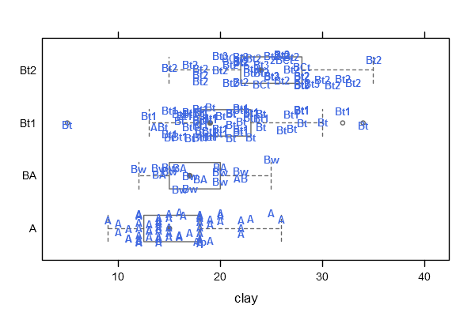

### Maximum-Likelihood Horizonation

The figure below describes the most likely horizonation, based on the collection of pedons associated with this component. This is only an estimate, expert knowledge should be used to adjust these values as needed. When pedon numbers are low or horizonation is not consistent, overlap can occur. Values in square brackets are related to [Brier Scores](http://en.wikipedia.org/wiki/Brier_score#Original_definition_by_Brier), smaller values suggest more consistent horizonation within the collection.

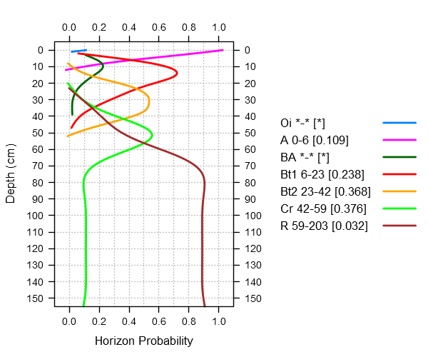

### Component Profile Plot

These profile sketches represent the entire collection of named components within the selected set, ordered by map unit symbol.

[figure not shown]

### Texture Class Summary Tables

These tables describe the frequency of textural classes, summarized by component, map unit and generalized horizon. Values within parenthesis are the fraction of horizons associated with each texture class.

| Generalized HZ | Texture Classes |
| --- | --- |
| Oi | SPM (1) |
| A | L (0.66), SIL (0.22), GR-L (0.03), GR-SIL (0.03), FSL (0.02), SL (0.02), ST-L (0.02) |
| BA | L (0.53), CN-L (0.13), CB-SIL (0.07), CBV-FSL (0.07), GR-L (0.07), SIL (0.07), SL (0.07) |
| Bt1 | L (0.32), GR-L (0.2), SIL (0.15), GR-SIL (0.05), CBV-L (0.03), CN-L (0.03), SICL (0.03), CB-L (0.02), CL (0.02), CN-SICL (0.02), GR- (0.02), GRV-CL (0.02), GRV-L (0.02), PGR-SICL (0.02), SCL (0.02), S… |
| Bt2 | L (0.27), GR-L (0.11), SIL (0.09), CBV-L (0.07), PGR-CL (0.07), PGRX-L (0.07), GR-CL (0.05), SICL (0.05), CB- (0.02), CL (0.02), CN-CL (0.02), CN-SCL (0.02), GR-SIL (0.02), GRV-CL (0.02), GRX-L (0.02)… |
| Cr | BR (1) |
| R | BR (1) |
|  | L (0.33), BR (0.21), GR-L (0.1), CL (0.05), GRV-L (0.05), SPM (0.05), C (0.03), CB (0.03), GR-SIL (0.03), GRV-CL (0.03), GRV-SICL (0.03), PCNX-L (0.03), PGR-SICL (0.03), SIL (0.03) |

### Morphologic Summary Tables

These table describe low-rv-high values for morphologic properties, summarized by component. The low values are the 0.05 percentile, RV values are the 0.5 percentile, and the high values are the 0.95 percentile.

[output not shown]

### Morphologic Summary by Map Unit

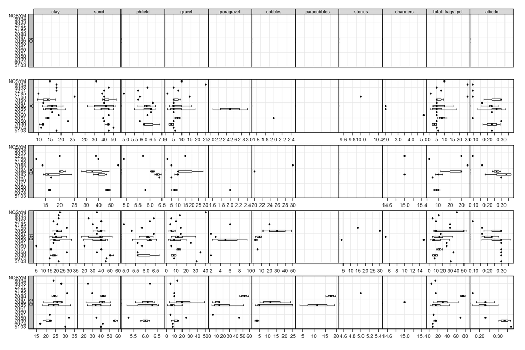

### Surface Fragment Summary Tables

These table describe low-rv-high values for surface rock fragments, summarized by component and map unit. The low values are the 0.05 percentile, RV values are the 0.5 percentile, and the high values are the 0.95 percentile.

| surface_gravel | surface_cobbles | surface_stones | surface_boulders | surface_channers | surface_flagstones | surface_paragravel | surface_paracobbles |
| --- | --- | --- | --- | --- | --- | --- | --- |
| 1-2-5 | 1-2-5 | 1-2-5 | 2-2-2 | NA-NA-NA | 2-5-8 | NA-NA-NA | NA-NA-NA |

### Diagnostic feature summary

The low values are the 0.05 percentile, RV values are the 0.5 percentile, and the high values are the 0.95 percentile.

| kind | N | top | bottom | thick |
| --- | --- | --- | --- | --- |
| argillic horizon | 59 | 3-7-25 | 24-38-49 | 13-26-44 |
| cambic horizon | 11 | 3-5-13 | 15-32-45 | 11-24-37 |
| lithic contact | 26 | 27-49-71 | 150-200-203 | 85-154-172 |
| mollic epipedon | 1 | 0-0-0 | 15-15-15 | 15-15-15 |
| ochric epipedon | 63 | 0-0-0 | 3-6-18 | 3-6-18 |
| paralithic contact | 49 | 25-41-49 | 40-55-131 | 5-14-94 |
| paralithic materials | 1 | 38-38-38 | 64-64-64 | 26-26-26 |

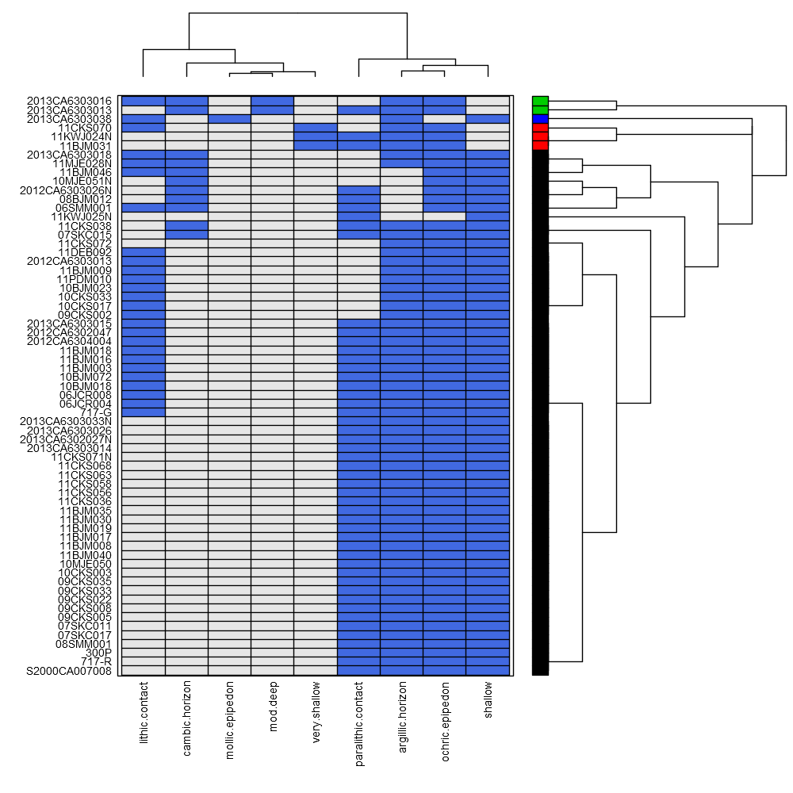

### Pedon GIS Summary

The low values are the 0.05 percentile, RV values are the 0.5 percentile, and the high values are the 0.95 percentile. These values were sampled from raster data sources, at each pedon location. Arrows on the circular histogram of field-measured aspect values are related to percentiles and “mean resultant length”, on a circular basis. Grey arrows are the 0.05 and 0.95 percentiles and the red arrow is the 0.5 percentile. Longer arrows suggest an aspect-affected pattern or aspect-biased sampling site selection.

| slope_field | gis_ppt | gis_tavg | gis_ffd | gis_elev | gis_solar | gis_mast | gis_slope |
| --- | --- | --- | --- | --- | --- | --- | --- |
| 4-12-35 | 437-591-783 | 16-16-17 | 228-238-270 | 126-282-479 | 55057-67518-71554 | 15-17-18 | 5-13-35 |

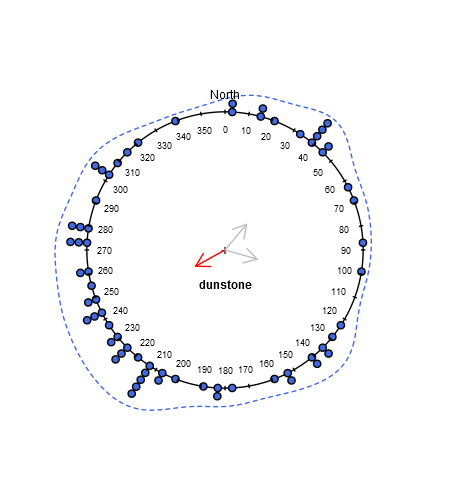

This document is based on `aqp` version 1.7-11 and `soilDB` version 1.4-7.